# Vector, Data types, if-else (W3)

2019-09-26

## vector

- 上週實習課使用 R 時，指令的回傳值多半只有「一個」。但 R 其實是一種以**向量**作為基本單位的程式語言，所以對於「一個回傳值」更精確的描述應該是「一個**長度為 1** 的向量」。

  ```r
  x <- 2
  x

  is.vector(x)
  length(x)
  ```

  ```
  #> [1] 2
  #> [1] TRUE
  #> [1] 1
  ```

- 我們上週簡短提過以 `:` 製造數列的方式 (e.g. `1:10`)。事實上，這個回傳的數列即是一個 vector。另外，由於這個 vector 的每個元素皆是整數，因此這個 vector 屬於 integer vector。我們可以使用 `typeof()` 確認 vector 的類別

  ```r
  typeof(1:10)
  ```

  ```
  #> [1] "integer"
  ```

- R 裡面的 vector 可以被分成 6 種類別，其中常見的 4 種分別為 `integer`, `double`, , `character`, `logical`

### integer vector

- integer vector 的元素由整數組成，它可以是零、正或負的。除了使用 `:` 製造數列，也可以使用 `c()` (稱為 concatenate) 組出任意序列的 vector。
  - 使用 `c()` 製造 integer vector 時，每個整數數字後面必須接 `L`，若沒有加上 `L`， R 會將製造出來的 vector 視為 double vector。

```r
int_vec <- c(-1L, 5L, 2L)
dbl_vec <- c(-1, 5, 2)
int_vec
dbl_vec

typeof(int_vec)
typeof(dbl_vec)
```

```
#> [1] -1  5  2
#> [1] -1  5  2
#> [1] "integer"
#> [1] "double"
```

### double vector

- double vector 儲存的是[浮點數](https://zh.wikipedia.org/wiki/%E6%B5%AE%E7%82%B9%E6%95%B0)，亦即含有小數點的數字 (e.g `1.2`, `-0.75`)
- 在 R 裡面，integer vector 與 double vector 合稱為 numeric vector，兩者之間的區隔通常也不太重要，因為 R 在運算時，通常會將這兩種資料類型自動轉換成合適的類型

  ```r
  typeof(2L)
  typeof(2.0)

  is.numeric(2L)
  is.numeric(2.0)
  ```

  ```
  #> [1] "integer"
  #> [1] "double"
  #> [1] TRUE
  #> [1] TRUE
  ```

  ```r
  typeof(1L + 1.0)
  typeof(1L / 2L)
  ```

  ```
  #> [1] "double"
  #> [1] "double"
  ```

- Special values:
  - `Inf`: 代表無限大
  - `NaN`: “Not a Number”，常見於數字運算不符數學定義時，例如：

    ```r
    0 / 0
    Inf / Inf
    log(-1)
    ```

    ```
    #> [1] NaN
    #> [1] NaN
    #> [1] NaN
    ```

### character vector

- 除了數字以外，R 也可以儲存**字串 (string)**。character vector 的每個元素皆由一個字串所組成。在 R 裡面，只要是被引號 (quote, `'` 或 `"` 皆可) 包裹的東西就是字串，放在引號內的可以是任何字元 (e.g. 空白、數字、中文字、英文字母)

  ```r
  "1.1"  # This is a string (or character vector of length 1), not double
  "你 好！"
  c("1.1", "你 好！")
  ```

  ```
  #> [1] "1.1"
  #> [1] "你 好！"
  #> [1] "1.1"     "你 好！"
  ```

- 如果字串內含有引號 `"`，需在字串內的引號前使用跳脫字元 `\`，以表示此引號是字串的一部分而非字串的開頭或結尾
  - 或是，你可以使用「不同的」引號。例如以「單引號」表示字串的開頭與結尾時，字串內就可以直接使用「雙引號」，反之亦然

  ```r
  "\""  # escape a double quote
  '\''  # escape a single quote
  '"'   # a double quote as string without escaping
  "'"   # a single quote as string without escaping
  ```

  ```
  #> [1] "\""
  #> [1] "'"
  #> [1] "\""
  #> [1] "'"
  ```

### logical vector

- logical vector 的每個元素由 `TRUE` 或 `FALSE` 組成。
- 可以使用 `c()` 一項項手動輸入製造 logical vector
- logical vector 的另一個來源則是 logical test 的回傳值：
  - logical operators: `==`, `!=`, `>`, `<`, `%in%`

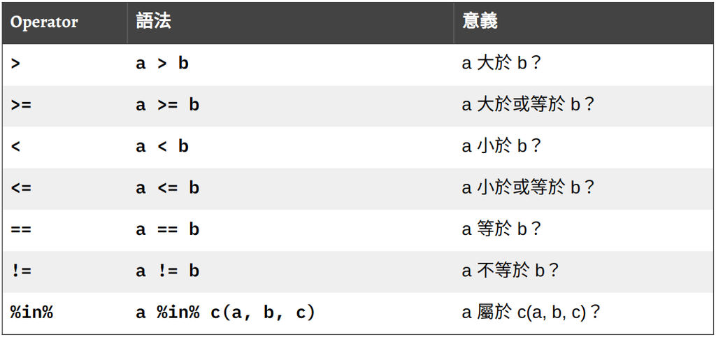

  ```r
  vec1 <- c(1, 1, 1)
  vec2 <- c(2, 0, 2)
  ```

  ```r
  # logical tests
  vec1 > vec2
  vec1 < vec2
  vec1 == vec2
  ```

  ```
  #> [1] FALSE  TRUE FALSE
  #> [1]  TRUE FALSE  TRUE
  #> [1] FALSE FALSE FALSE
  ```

- boolean operators (`&`, `|`, `!`, `any()`, `all()`) 可以整合**多個** logical tests

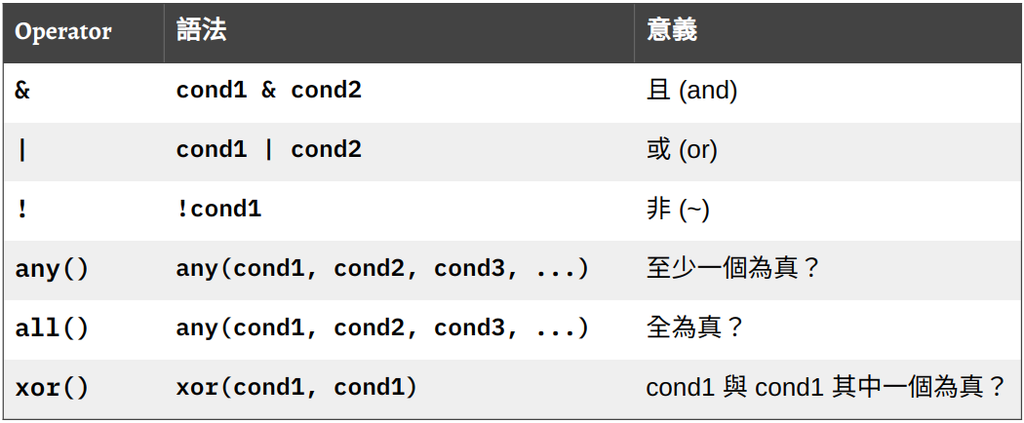

  ```r
  TRUE & TRUE
  TRUE & FALSE
  TRUE | FALSE
  !TRUE
  ```

  ```
  #> [1] TRUE
  #> [1] FALSE
  #> [1] TRUE
  #> [1] FALSE
  ```

  ```r
  (1 == 1) & (2 == 2)
  ```

  ```
  #> [1] TRUE
  ```

### NA

- `NA` 代表的是「缺失值」，可以作為任何一種 vector 裡面的元素。當 `NA` 出現在 vector 中，函數對於 vector 的運算常會出現令人意外的結果:

  ```r
  10 > NA
  ```

  ```
  #> [1] NA
  ```

  ```r
  NA == NA
  ```

  ```
  #> [1] NA
  ```

  ```r
  vec <- c(1, NA, 2, 3)
  mean(vec)
  ```

  ```
  #> [1] NA
  ```

  ```r
  mean(vec, na.rm = TRUE)
  ```

  ```
  #> [1] 2
  ```

## Recycling

- 兩個或兩個以上的 vector 進行運算時，通常是以 **element-wise** 的方式進行。此時，若進行運算的 vector 長度不相同，例如，`c(1, 2, 3) + 2`， R 會自動將長度較短 vector (`2`) 「回收 (recycle)」，亦即，重複此向量內的元素使其「拉長」到與另一個 vector 等長；接著再將兩個一樣長的 vector 進行 element-wise 的向量運算。

```r
x <- c(1, 1, 2, 2)

# Arithmetic operation
x + 2  # equivalent to...
x + c(2, 2, 2, 2)
```

```
#> [1] 3 3 4 4
#> [1] 3 3 4 4
```

```r
x <- c(1, 1, 2, 2)

# Logical operation
x == 2  # equivalent to...
x == c(2, 2, 2, 2)
```

```
#> [1] FALSE FALSE  TRUE  TRUE
#> [1] FALSE FALSE  TRUE  TRUE
```

```r
# String operation
long <- c("a", "b", "c")
short <- "1"
paste0("a", "1")
paste0(long, short)
```

```
#> [1] "a1"
#> [1] "a1" "b1" "c1"
```

## Coercion

- vector 內的每個元素，其資料類型 (data type) 必須相同。資料類型即是前面提到的 `integer`, `double`, `character`, `logical`。
- 若發生資料類型不一致的情形 (e.g. 將不同資料類型的元素放入 `c()`)，R 會根據某些**規則**，**自動**進行資料類型的轉換。這個過程在 R 裡面稱為 Coercion

  ```r
  c(TRUE, FALSE, 3)      # logical & numeric
  c(-1, "aa")            # numeric & character
  c(FALSE, TRUE, "hi!")  # logical & character
  c(TRUE, 0, "hi!")      # logical & numeric & character
  ```

  ```
  #> [1] 1 0 3
  #> [1] "-1" "aa"
  #> [1] "FALSE" "TRUE"  "hi!"
  #> [1] "TRUE" "0"    "hi!"
  ```

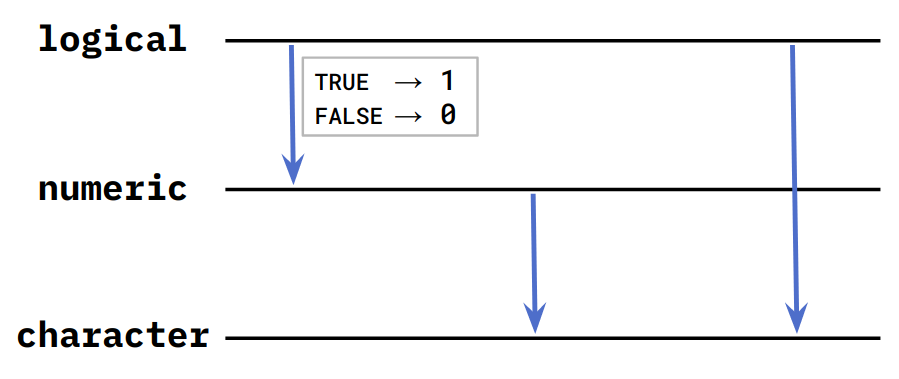

Rules of Coercion

- if coercion failed, throw error
- manual coercion: `as.character()`, `as.logical()`, `as.numeric()`

```r
sum(c(T, T, T, F))

gender <- c("male", "female", "male", "female")
sum(gender == "male")  # num of male
mean(gender == "male")  # proportion of male
```

```
#> [1] 3
#> [1] 2
#> [1] 0.5
```

## Subsetting a vector

- 有 3 種方法可用於取出 vector 裡面的元素 (回傳一個新的 vector)
  1. 透過提供 vector 中元素的位置次序 (index)
  2. 透過一個與此 vector 等長的 logical vector。在 logical vector 中的相對應位置，以 `TRUE` 或 `FALSE` 表示是否保留該位置的元素
  3. 透過提供元素的「名字」(i.e. `names` 屬性)

### index subsetting

```r
# z[<integer_vector>]
LETTERS  # R 內建變數: 包含所有大寫英文字母的 character vector
```

```
#>  [1] "A" "B" "C" "D" "E" "F" "G" "H" "I" "J" "K" "L" "M" "N" "O" "P" "Q"
#> [18] "R" "S" "T" "U" "V" "W" "X" "Y" "Z"
```

```r
LETTERS[1]
```

```
#> [1] "A"
```

```r
LETTERS[1:5]
```

```
#> [1] "A" "B" "C" "D" "E"
```

```r
LETTERS[c(1, 3, 5)]
```

```
#> [1] "A" "C" "E"
```

```r
LETTERS[-(1:5)]  # Exclude the first 5 elements
```

```
#>  [1] "F" "G" "H" "I" "J" "K" "L" "M" "N" "O" "P" "Q" "R" "S" "T" "U" "V"
#> [18] "W" "X" "Y" "Z"
```

### Logical subsetting

```r
# z[<logical_vector of length(z)>]
age <- c(21, 20, 18, 19)
age[c(FALSE, TRUE, FALSE, TRUE)]
```

```
#> [1] 20 19
```

```r
## Creating logical vectors
age[1] < 20  # returns a logical vector of length 1
```

```
#> [1] FALSE
```

```r
age < 20     # returns a logical vector of length(x)
```

```
#> [1] FALSE FALSE  TRUE  TRUE
```

```r
# Subset a vector using a logical test
age[age < 20]
```

```
#> [1] 18 19
```

### Subsetting with names

```r
age <- c(40, 20, 18, 19)
names(age) <- c("kai", "jessy", "joy", "yola")
# age <- c(kai = 40, jessy = 20, joy = 18, yola = 19)  # another way of setting names

age
```

```
#>   kai jessy   joy  yola
#>    40    20    18    19
```

```r
age['kai'] + 9
```

```
#> kai
#>  49
```

```r
age[c('jessy', 'kai')]
```

```
#> jessy   kai
#>    20    40
```

### Modifying Values in vector

```r
a2z <- LETTERS
a2z[1:3] <- c("a", "b", "c")
a2z
```

```
#>  [1] "a" "b" "c" "D" "E" "F" "G" "H" "I" "J" "K" "L" "M" "N" "O" "P" "Q"
#> [18] "R" "S" "T" "U" "V" "W" "X" "Y" "Z"
```

```r
gender <- c("m", "m", "f", "f")
gender[gender == "m"] <- "male"
gender
```

```
#> [1] "male" "male" "f"    "f"
```

```r
gender[gender == "f"] <- "female"
gender
```

```
#> [1] "male"   "male"   "female" "female"
```

```r
names(gender) <- c("john", "jenny", "jane", "kate")
gender
```

```
#>     john    jenny     jane     kate
#>   "male"   "male" "female" "female"
```

```r
gender["john"] <- "male"
gender
```

```
#>     john    jenny     jane     kate
#>   "male"   "male" "female" "female"
```

```r
gender[c("jenny", "jane", "kate")] <- "female"
gender
```

```
#>     john    jenny     jane     kate
#>   "male" "female" "female" "female"
```

## if else

- 一般而言，R 是**由上至下一行一行地執行程式碼**。有時候我們會希望能**跳過某些程式碼**或是**依據不同的狀況執行不同的程式碼**，這時候我們就需要使用**條件式**。

```r
x <- 1

if (x > 0) {
    print('x is positive')
} else {
    print('x is not positive')
}
```

```
#> [1] "x is positive"
```

```r
x <- -1

if (x > 0) {
    print('x is positive')
} else if (x < 0) {
    print('x is negative')
} else {
    print('x is zero')
}

print('This is always printed')
```

```
#> [1] "x is negative"
#> [1] "This is always printed"
```

- 在 `if`-`else if`-`else` 的結構中，只有**其中一個**區塊 (被大括弧 `{}` 包裹的程式碼) 會被執行。執行完該區塊後，就會忽略剩下的條件控制區塊，執行條件式之後的程式碼。
- 可以在 `if` 之後使用多個 `else if`.
- 條件式的結構：

  ```r
  # 只有 if
  if (<條件>) {
      <Some Code>  # 條件成立時執行
  }

  # if, else
  if (<條件>) {
      <Some Code>  # <條件>成立時執行
  } else {
      <Some Code>  # <條件>不成立時執行
  }

  # if, else if, else
  if (<條件1>) {
      <Some Code>          # <條件1>成立時執行
  } else if ( <條件2> ) {
      <Some Code>          # <條件1>不成立、<條件2>成立時執行
  } else {
      <Some Code>          # <條件1>、<條件2>皆不成立時執行
  }
  ```

## Wrap up: 句子產生器

```r
# Data
name <- c("kai", "jessy", "joy", "yola")
age <- c(40, 20, 18, 19)
about <- c("a professor", "a cat lover", "a hacker", "a YouTuber")

# Randomly draw 2 subjects
draws <- sample(1:4, size = 2)

# Find out who is older
if (age[draws[1]] > age[draws[2]]) {
    comparitive <- 'is older than'
} else if (age[draws][1] < age[draws][2]) {
    comparitive <- 'is younger than'
} else {
    comparitive <- 'is the same age as'
}

# Construct sentence
roles <- paste0(name[draws], ", " , about[draws])
roles
```

```
#> [1] "yola, a YouTuber" "joy, a hacker"
```

```r
paste0(roles[1], ", ", comparitive, " ", roles[2], ".")
```

```
#> [1] "yola, a YouTuber, is older than joy, a hacker."
```

## 配合課本

- Hands-on programming with R
  - [R Objects](https://rstudio-education.github.io/hopr/r-objects.html)
  - [Modifying Values](https://rstudio-education.github.io/hopr/modify.html)